# ESM 204 HW 3

Author

Dustin Duncan

```r
rm(list = ls())
library(tidyverse)
library(pracma)
library(stats)
```

**Reading in data**

```r
dac_sd_df <- read.csv("data/HW3_data.csv") %>%
  janitor::clean_names()

## Price in $ and Q is in number of EV's

# Current EV price without intervention is 50,000 per vehicle
# There is no intervention initially in the market
# marginal cost of producing an EV is linear and has a price intercept of zero
```

## 1 Questions

### 1.1 1. Run lm’s to estimate demand curves for DAC and nonDAC consumers

```r
# Running linear model to obtain price as a function of quantity for Dac and NonDac, then pulling out [[1]] for a (intercept), and [[2]] for b (slope) for both
dac_demand <- lm(price_dollars ~ q_dac, data = dac_sd_df)
a <- dac_demand$coefficients[[1]]
b <- dac_demand$coefficients[[2]]
non_dac_demand <- lm(price_dollars ~ q_non_dac, data = dac_sd_df)
a1 <- non_dac_demand$coefficients[[1]]
b1 <- non_dac_demand$coefficients[[2]]
a
```

```
[1] 116854.8
```

```r
b
```

```
[1] -6.611437
```

```r
a1
```

```
[1] 158034.3
```

```r
b1
```

```
[1] -2.730926
```

**Formulas for demand curves from linear regression results**

$$\begin{align}
\mathrm{P_{DAC}=116855 - 6.611Q} \\
\mathrm{Q_{DAC} = 17675.69 - 0.151P} \\
\mathrm{P_{nonDAC}=158034 -2.731Q} \\
\mathrm{Q_{nonDAC} = 57866.72 - 0.366P}
\end{align}$$

#### 1.1.1 What are 2-3 reasons you can think that may explain the differences in demand you estimate?

**Disadvantaged communities may have a demand for electric vehicles because fuel-injection vehicles are less expensive and easier to repair (without hiring a mechanic) than electric vehicles. In addition, Non-disadvantaged communities may have a higher demand for electric vehicles due to their income demographics (i.e. they have the resources to pay more for an electric vehicle versus a fuel-injection), or the more abundant EV charging infrastructure seen in wealthier communities may lead to them being more convenient to use in a non-disadvantaged community as compared to a disadvantaged one.**

### 1.2 2. Marginal external cost per each EV produced

**One kg of lithium causes $300 worth of damage in health costs to local communities living near mines. Each EV requires a lithium ion battery containing 63kg of lithium**

$$\begin{align}
\frac{300}{1kgLi}*\frac{63kgLi}{1EV}=\frac{18,900}{EV} \\
~ \\
MEC = 18,900 + 0Q
\end{align}$$

### 1.3 3. Describe the current equilibrium

#### 1.3.1 a: What is the aggregate annual demand curve for EV’s?

$$\begin{align}
\mathrm{Q_{DAC}=17675.69 -.151P} \\
+\\
\mathrm{Q_{nonDAC}=57866.72-.366P} \\
=\\
\mathrm{Q_{AGG}=75542.41 -0.517P}
\end{align}$$

```r
# Sequencing price to calculate Quantity demanded at a given price as well as aggregate demand
P = seq(0, 200000, by = 1)

## Writing inverse demand function that calculates Qdac, Qnon-dac (Qndac),
demand <- function(P){
  Qdac = 17675.69 - 0.151*P
  Qndac = 57866.72 - 0.366*P
  # Qagg = 75542.41 - 0.517*P
  Qagg = ifelse(Qdac <= 0, (57866.72 - 0.366*P), (75542.41 - 0.517*P))
  return(tibble(Qdac = Qdac, Qndac=Qndac, Qagg=Qagg, P=P))
}

test <- demand(P)

baseline <- demand(50000)
```

#### 1.3.2 b: What is the supply curve for EV’s?

**To derive the supply curve for EV’s we will use the knowledge that when price is zero, quantity is also zero; this is our initial (X,Y). Next, we will use the current EV price of $50,000 without intervention as our Y2, and the Qagg at P=50000 will act as X2 (Qagg(50000),50000) to calculate the slope of the supply curve.**

```r
# baseline$Qagg
50000/baseline$Qagg
```

```
[1] 1.00619
```

$$\begin{align}
\mathrm{\frac{\triangle{Y}}{\triangle{X}}} \\
= \\
\mathrm{\frac{50000-0}{49692-0}} \\
= \\
\mathrm{\frac{50000}{49692}} \\
= \\
1.01 \\
\mathrm{P_{sup}=0 + 1.01Q}
\end{align}$$

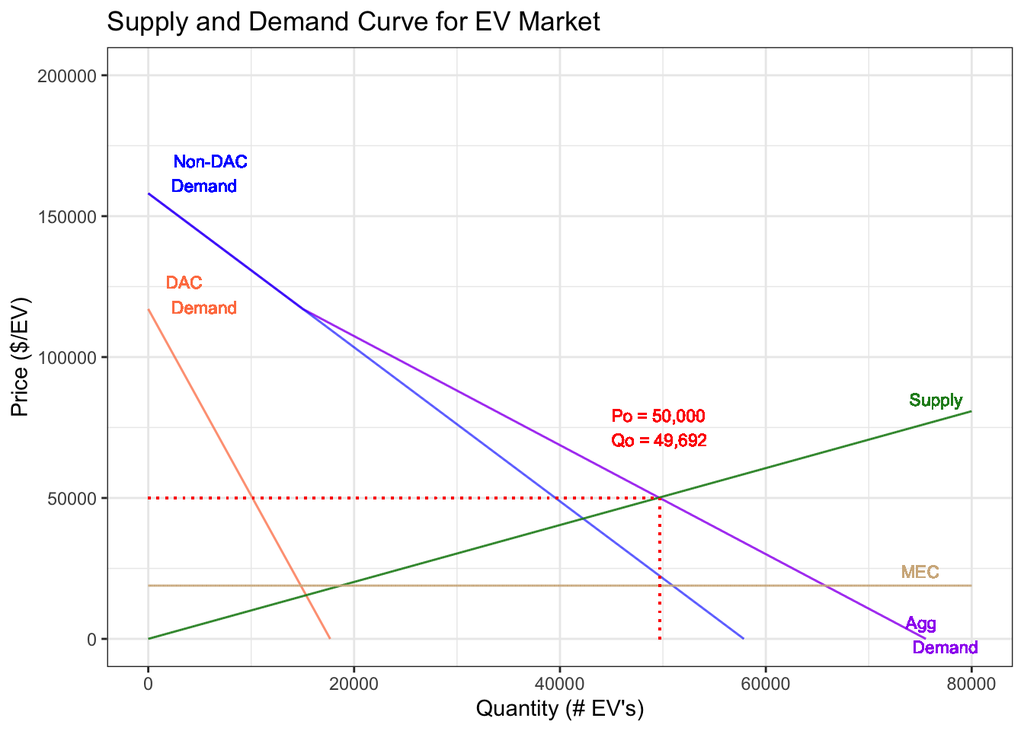

```r
## Writing function to calculate the quantity supplied at a given price from the above formula
supply <- function(P) {
  Qsup = P/1.01
  return(tibble(Qsup = Qsup))
}
## Calculating supply over the price that I sequenced earlier and storing it in test2 dataframe
test2 <- supply(P)

## Using cbind to add Qsup from test2 to the demand df (test) to plot together
test_all <- test %>% cbind(Qsup = test2$Qsup)

## Using rep to add an 'mec' column to test_all dataframe that just repeats 18900, this way I can plot the MEC
test_all$mec <- rep(18900, n=200000)

## Plotting supply curve, demand curves, and indicating the quantity demanded at the current price of $50,000
ggplot(data = test_all) +
  geom_line(aes(x = Qdac, y = P), color = "coral") +
  geom_line(aes(x = Qagg, y = P), color = "purple") +
  geom_line(aes(x = Qndac, y = P), color = "blue", alpha = 0.75) +
  geom_line(aes(x = Qsup, y = P), color = "forestgreen") +
  geom_line(aes(x = Qsup, y = mec), color = "tan") +
  geom_segment(aes(x = 0, xend = baseline$Qagg, y = 50000, yend=50000), color = "red", linetype = "dotted") +
  geom_segment(aes(x = baseline$Qagg, xend = baseline$Qagg, y = 0, yend=50000), color = "red", linetype = "dotted") +
  geom_text(aes(x = 1000, y = 116854), label = "DAC\nDemand", size = 3, color = "coral", vjust = 0.1, hjust = -0.2) +
  geom_text(aes(x = 1000, y = 160000), label = "Non-DAC\nDemand", size = 3, color = "blue", hjust = -0.2, vjust = 0.1) +
  geom_text(aes(x = 73000, y = 1500), label = "Agg\nDemand", size = 3, color = "purple", hjust = -0.2) +
  geom_text(aes(x = 75000, y = 85000), label = "Supply", size = 3, color = "forestgreen", hjust = 0.2) +
  geom_text(aes(x = 45000, y = 75000), label = "Po = 50,000\nQo = 49,692", size = 3, color = "red", hjust = 0, vjust = 0.5) +
  geom_text(aes(x = 75000, y = 23000), label = "MEC", size = 3, color = "tan", vjust = 0.3) +
  theme_bw() +
  labs(x = "Quantity (# EV's)", y= "Price ($/EV)") +
  ggtitle("Supply and Demand Curve for EV Market") +
  xlim(0, 80000)
```

#### 1.3.3 c: What is the “benefit” to consumers under the status quo?

```r
area_above_Qdac = 0.5*((17675.69-0)*(158034-116855)) # upper triangle
between_Qdac_Po = (17675.69-0)*(116855-50000) # middle rectangle
past_Qagg = 0.5*((116855-50000)*(49962-17675.69)) # lower triangle
# Consumer benefit will be output of the following:
consumer_benefit = area_above_Qdac + between_Qdac_Po + past_Qagg
```

#### 1.3.4 d: What is the “benefit” to producers under the status quo?

**The benefit to producers under the status quo can be calculated by taking the area of the triangle between the Supply curve and the current price dashed line, up until the intersection of the supply curve and the aggregate demand curve**

```r
# Producer benefit
0.5*((50000)*(49962))
```

```
[1] 1249050000
```

#### 1.3.5 e: What is the environmental cost under the status quo?

**The environmental cost under the status quo can be calculated by taking the area underneath the MEC curve where it meets the current aggregate demand**

```r
## Because it is a rectangle, just length (Qagg = 49962) x height (MEC = 18900)
18900*49962
```

```
[1] 944281800
```

### 1.4 4. How is the current consumer benefit divided between DAC and non-DAC consumers?

```r
## Writing function that takes price (P), a demand function (demandfunc), and the price at Q=0 for each consumer group: Non-DAC (an), and DAC (ad). This function then calculates the area between the highest price they're willing to pay(an, ad), the current price (P), as well as calculates the quantity they will buy at the current price using the above demand function. The $ is added because the above demand function output is a df, so I know that the variables I want to extract (which is what is actually being multiplied) are Qndac and Qdac. Then returns a dataframe with each consumer groups' consumer benefit
CS <- function(P, demandfunc, an, ad){
  CSn = 0.5*(an-P)*demandfunc(P)$Qndac
  CSd = 0.5*(ad-P)*demandfunc(P)$Qdac
  return(tibble(CSn=CSn, CSd=CSd))
}

benefit <- CS(50000, # current price
              demandfunc = demand, # demand function to calculate Qndac + Qdac
              an=a1, # Price intercept when Q is zero for non-dac
              ad=a) # Price intercept when Q is zero for non-dac

## Adding each consumer benefit to calculate the total (different method from above because it sounded frustrating to differentiate between the two consumers)
totalbenefit = benefit$CSn + benefit$CSd

## Calculating non-dac benefit by dividing by total, then multiplying by 100 to get percentage and rounding for a number without 9 decimals
ndac_benefit = round((benefit$CSn)/totalbenefit*100)

## Same process as above but for dac benefit percentage
dac_benefit = round((benefit$CSd)/totalbenefit*100)

cat("Non-DAC consumers' share of the current consumer benefit is about", ndac_benefit,"%, whereas DAC consumers' share is about", dac_benefit, "%" )
```

```
Non-DAC consumers' share of the current consumer benefit is about 86 %, whereas DAC consumers' share is about 14 %
```

### 1.5 5. Derive the optimal EV tax (in $ per vehicle) to internalize the lithium mining externality. Noting that recent research has shown that DACs are far more likely to contain mining activity, assume that the mining externality is borne entirely by the DAC group. What would be the effects of this tax on:

**Deriving the optimal EV tax in $ per vehicle to internalize the lithium mining externality would imply that the supply curve would shift up to account for the external cost of 18900 per EV (Vertical sum of MEC and MPC). Since MEC is constant per vehicle, this would entail just adding 18900 to the supply curve, which would give us the MSC, as well as the tax of 18,900 dollars per vehicle.**

$$\begin{align}
if \\
\mathrm{Q_{Dagg} = 75542.41 -0.517P} \\
then \\
\mathrm{P = 146116.8 - 1.93Q_{Dagg}} \\
...\\
P = MSC \\
\mathrm{146116.8 -1.93Q = 18900 + 1.01Q} \\
\mathrm{127216.8=2.94Q} \\
\mathrm{Q^{*}=43271.02} \\
\mathrm{P^{*}(from~MSC) = 18900+1.01*(43271.02)} \\
\mathrm{P^{*}=62603.73}
\end{align}$$

#### 1.5.1 a/b: The amount of EV’s Produced and consumed and their price

```r
## Writing a function in R to do this for me

## Specify msc formula as a function of Q
msc <- function(Q){
  P = 18900 + 1.01*Q
  return(P)
}

## Specifying aggregate demand formula as a function of Q
dagg <- function(Q){
  P = 146116.8 - 1.93*Q
  return(P)
}
## Writing equilibrium function to calculate their difference
equilibrium <- function(Q){
  E <- dagg(Q) - msc(Q)
  return(E)
}

## Plugging it into fzero to return the equilibrium quantity
qstar <- fzero(function(Q) equilibrium(Q), 50000)$x

## Plugging the equilibrium quantity into the dagg function to obtain pstar
pstar <- dagg(qstar)

## Checking answer with msc function
# pstar_check <- msc(qstar) They are the same

cat("The new amount of EV's consumed:", qstar, "\nThe new price of EV's: $", pstar)
```

```
The new amount of EV's consumed: 43271.02
The new price of EV's: $ 62603.73
```

#### 1.5.2 c/d: Overall welfare of non-DAC consumers and Overall welfare of DAC consumers

```r
## Using above CS function to calculate the new consumer surplus, but adding on to it to include that the externality is borne entirely by the DAC group. In this case it will be their Consumer surplus minus the environmental damage at Qagg, because they are bearing the externality
CS <- function(P, demandfunc, an, ad, mec, Qagg){
  CSn = 0.5*(an-P)*demandfunc(P)$Qndac
  CSd = 0.5*(ad-P)*demandfunc(P)$Qdac - mec*Qagg
  return(tibble(CSn=CSn, CSd=CSd))
}

new_welfare <- CS(P=pstar, # Equilibrium price under with tax
   demandfunc=demand, # same demand function as above
   an = a1, # Initial price Non-DAC is willing to pay at Q=0
   ad=a, # Initial price DAC is willing to pay at Q=0
   mec=18900, # Marginal external cost height (of rectangle)
   Qagg=qstar) # Marginal external cost base, which is new eq. Quantity (Qagg)

cat("The new overall wellfare of non-DAC consumers: $", new_welfare$CSn, "\nThe new overall wellfare of DAC consumers: $", new_welfare$CSd)
```

```
The new overall wellfare of non-DAC consumers: $ 1667828006
The new overall wellfare of DAC consumers: $ -594781706
```

#### 1.5.3 e: EV producers

```r
## Writing function to calculate the PS benefit at new pstar and qstar
PS <- function(P, Q){
  PS=0.5*(P-0)*Q
  return(PS)
}

## Throwing it into a df called 'ps'
ps = PS(pstar,qstar)

cat("The new producer surplus for EV producers is: $", ps)
```

```
The new producer surplus for EV producers is: $ 1354463652
```

#### 1.5.4 f: Total environmental damage

**The new total environmental damage can be calculated by multiplying the equilibrium quantity of EV’s produced by the MEC at that point**

```r
## Just the rectangles area
ted = 18900*qstar
cat("The new total environmental damage: $", ted)
```

```
The new total environmental damage: $ 817822286
```

#### 1.5.5 g: Total tax revenue generated

**The total tax revenue generated would be equal to total environmental damage, because it is the tax multiplied by the quantity consumed**

```r
cat("The total tax revenue generated: $", ted)
```

```
The total tax revenue generated: $ 817822286
```

### 1.6 6. Now, assume that all revenue from the EV tax will be redistributed to the consumers in proportion to their pre-tax consumption of EVs. For example, if 80% of the EVs were consumed by non-DAC consumers, then they get 80% of the tax revenue. Calculate the effects of this EV tax on:

#### 1.6.1 a: Overall welfare of non-dac consumers

#### 1.6.2 b: Overall welfare of dac consumers

#### 1.6.3 c: EV producers

```r
## First I will need to calculate the proportion of EV's consumed by non-DAC and DAC consumers pre-tax. My function for demand already calculated this for me and stored it in the 'baseline' df. so Im just going to call my variables out of the dataframe to calculate the proportions, and store them as objects so its easier to follow

prop_ndac = baseline$Qndac/(baseline$Qagg)

prop_dac = baseline$Qdac/(baseline$Qagg)

## Now to calculate the overall welfare of either group after redistribution, I will multiply their proportion of consumption by the total tax revenue, and add that to their new overall welfare calculated in question 5. Each of the consumers' wellfare values are stored in the 'new_welfare' df.

dist_welfare_nDAC = prop_ndac*ted + new_welfare$CSn

dist_welfare_DAC = prop_dac*ted + new_welfare$CSd

cat("The overall wellfare of non-DAC consumers after the redistribution of the tax would be: $", dist_welfare_nDAC, "\nThe overall wellfare of DAC consumers after the redistribution, with the fact that they still bore the entire externality, would be: $", dist_welfare_DAC, "\nThe new producer surplus for EV producers would be unchanged at: $", ps)
```

```
The overall wellfare of non-DAC consumers after the redistribution of the tax would be: $ 2319004824
The overall wellfare of DAC consumers after the redistribution, with the fact that they still bore the entire externality, would be: $ -428136238
The new producer surplus for EV producers would be unchanged at: $ 1354463652
```

### 1.7 7. Based on your findings, use 1-3 sentences to answer the following (qualitatively only):

```r
## Because I dont feel like writing down the values themselves, I wrote this bit of code to just tell me which different 'benefit' inputs (for each consumer group) were larger than others. Below it are the values I used by just replacing them for each test.

## Non-DAC variable benefits
# benefit$CSn        ## initial
# new_welfare$CSn    ## with tax
# dist_welfare_nDAC  ## With redistribution

## DAC variable benefits
# benefit$CSd        ## initial
# new_welfare$CSd    ## with tax
# dist_welfare_DAC   ## With redistribution

## And this is the test. Print "True" if first value input is larger than second, or "False" if it isn't
# if (dist_welfare_DAC > benefit$CSd) {
#   cat("True")
# } else {
#   cat("False")
# }

## Non-DAC: new_welfare smaller than initial welfare because of tax, but the distributed welfare is greater than new welfare, as well as the initial welfare

## DAC: Distributed welfare is smaller than the initial welfare (not including the externality), but larger than the new_welfare with the externality associated with EV's, and new_welfare is naturally smaller than initial welfare
```

#### 1.7.1 a: Are non-DAC consumers likely to support the EV tax? How would the redistribution regime in question #6 affect their support for the tax?

**Non-DAC consumers are not likely to support the tax because under the EV tax, their overall welfare is smaller than it was without the tax, due to the increased price of EV’s. However, when the redistribution regime comes in, they would be likely to support it because their overall welfare under the redistribution regime would be greater than both their initial and post-tax, pre-distribution welfare.**

#### 1.7.2 b: Are DAC consumers likely to support the EV tax? How would the redistribution regime in question #6 affect their support for the tax?

**DAC consumers are not likely to support the tax because under the EV tax, DAC consumers are bearing the externality associated with mining, which reduces their overall welfare to a loss, rather than a benefit. With the redistribution regime, DAC consumers’ welfare is higher than without the regime, but still a loss compared to their initial welfare. So, if they were given a choice between tax/no tax, they would prefer no tax, but if they were given a choice between employing the redistribution regime or not, they would likely support the redistribution regime, all else being held constant.**